# NOAA Storm Database Analysis

Xavier Gutierrez

Thursday, June 18, 2015

## Synopsis

The purpose of the analysis is to answer two questions using the storm data from the National Weather Service. The questions are: 1. Across the United States, which types of events (as indicated in the EVTYPE variable) are most harmful with respect to population health? 2. Across the United States, which types of events have the greatest economic consequences? In order to do that, the file provided in the course website will be used as a data source. The file can be found under the following URL at the moment of performing this analysis:  
https://d396qusza40orc.cloudfront.net/repdata%2Fdata%2FStormData.csv.bz2

The .pdf file (Storm Data Preparation) explaining the mapping of events can be found here:  
https://d396qusza40orc.cloudfront.net/repdata%2Fpeer2_doc%2Fpd01016005curr.pdf

Note that both questions start with “Across the United States”, which I interpret in the way that the geography related information isn’t relevant and can be summarized across (either by averaging or summing).

## Data Processing

Firstly, data will be downloaded from the internet, unzipped and loaded into R as a Data Frame. The following chunk of code will be cached due to the duration of both the download and the loading of the data. As the raw data file takes a long time to download, the code will check if it is already present and not download if that is the case. Also, this code chuk is cached so that, if the raw data are already loaded in memory, the data load operation is not repeated.

```r
fileURL <- paste("https://d396qusza40orc.cloudfront.net/",
              "repdata%2Fdata%2FStormData.csv.bz2",sep="")
destFile <- "./repdata-StormData.csv.bz2"
if (!file.exists(destFile)) {
        download.file(fileURL,destFile)
}
NOAA_raw <- read.csv(destFile)
```

In order to prepare the data to be processed, a new data frame will be put together consisting only of the relevant columns for the analysis that needs to be performed. Otherwise, calculation times will be very long. Since we need to answer the two questions previously mentioned, we will reduce the data set to the columns `EVTYPE`, `FATALITIES` and `INJURIES` for the first question (population health related) and `PROPDMG` and `CROPDMG` in addition to `EVTYPE` for the second question (about economic consequences). The reason to exclude population related variables in the economic consequences is merely for simplicity purposes.

This is the code that copies the desired columns into a new data frame. Package `dplyr` is used to summarize across the variables that are not required. Two new data frames are created as a result: `NOAA_econ` (with the data to be used for economic consequences analysis) and `NOAA_popu` (for the population health analysis).

```r
library(dplyr)
p2_vars <- c("EVTYPE", "FATALITIES", "INJURIES", "PROPDMG", "CROPDMG")
NOAA_P2 <- NOAA_raw[p2_vars] %>%
        filter(FATALITIES != 0 | INJURIES != 0 | PROPDMG != 0 | CROPDMG != 0)

NOAA_econ <- NOAA_P2 %>% group_by(EVTYPE) %>%
        summarize(econ_cons = sum(PROPDMG + CROPDMG)) %>%
        arrange(desc(econ_cons))
NOAA_popu <- NOAA_P2 %>% group_by(EVTYPE) %>%
        summarize(popul_health = sum(FATALITIES + INJURIES)) %>%
        arrange(desc(popul_health))
```

This still results in a high amount of observations (488 for `NOAA_popu` and 488 for `NOAA_econ`). A quick glance at the data shows that this is a data cleanliness issue, with multiple different names for the same type of event.

```r
event_types <- sort(unique(as.factor(c(as.character(NOAA_popu$EVTYPE),
                                       as.character(NOAA_econ$EVTYPE)))))
thunderst <- event_types[grep("*THUNDERSTORM*|*TSTM*", event_types,
                              ignore.case=TRUE)]
```

As an example, all these types correspond to thunderstorm damage (incomplete listing for example purposes):

```r
thunderst
```

```
##  [1]  TSTM WIND                      TSTM WIND (G45)
##  [3] FLASH FLOODING/THUNDERSTORM WI LIGHTNING AND THUNDERSTORM WIN
##  [5] LIGHTNING THUNDERSTORM WINDS   MARINE THUNDERSTORM WIND
##  [7] MARINE TSTM WIND               NON-TSTM WIND
##  [9] NON TSTM WIND                  SEVERE THUNDERSTORM
## [11] SEVERE THUNDERSTORM WINDS      SEVERE THUNDERSTORMS
## [13] THUNDERSTORM                   THUNDERSTORM  WINDS
## [15] THUNDERSTORM DAMAGE TO         THUNDERSTORM HAIL
## [17] THUNDERSTORM WIND              THUNDERSTORM WIND (G40)
## [19] THUNDERSTORM WIND 60 MPH       THUNDERSTORM WIND 65 MPH
## [21] THUNDERSTORM WIND 65MPH        THUNDERSTORM WIND 98 MPH
## [23] THUNDERSTORM WIND G50          THUNDERSTORM WIND G52
## [25] THUNDERSTORM WIND G55          THUNDERSTORM WIND G60
## [27] THUNDERSTORM WIND TREES        THUNDERSTORM WIND.
## [29] THUNDERSTORM WIND/ TREE        THUNDERSTORM WIND/ TREES
```

[output cut: 23 more lines]

Therefore, the following rules will be applied (in the order they appear below) to clean-up the `EVTYPE`, consisting of strings to be found in the values of `EVTYPE` and their replacement:

```r
write.csv(event_types, file = "event_types.csv")
# Manual processing goes here in order to do the mapping of the 488 values to
# the 48 standard from the .pdf document explaining the standard types.
new_event_types <- read.csv("./new_evtype.csv", sep=";")
new_event_types %>% arrange(New_EVTYPE)
```

```
##      ID                         EVTYPE               New_EVTYPE
## 1     9          ASTRONOMICAL LOW TIDE    Astronomical Low Tide
## 2    10                       AVALANCE                Avalanche
## 3    11                      AVALANCHE                Avalanche
## 4   247                      LANDSLIDE                Avalanche
## 5   248                     LANDSLIDES                Avalanche
## 6   249                      Landslump                Avalanche
## 7   250                      LANDSPOUT                Avalanche
## 8   284                      MUD SLIDE                Avalanche
## 9   285                     MUD SLIDES                Avalanche
## 10  287                       Mudslide                Avalanche
## 11  288                       MUDSLIDE                Avalanche
## 12  289                      Mudslides                Avalanche
## 13  290                      MUDSLIDES                Avalanche
## 14  313                     ROCK SLIDE                Avalanche
```

[output cut: 474 more lines]

After that, the values of `EVTYPE` are replaced using the data in `new_event_types`:

```r
NOAA_popu_new <- NOAA_popu
NOAA_econ_new <- NOAA_econ
NOAA_popu_new$EVTYPE <- as.character(NOAA_popu$EVTYPE)
NOAA_econ_new$EVTYPE <- as.character(NOAA_econ$EVTYPE)
for (i in 1:nrow(new_event_types)){
        c <- as.character(new_event_types[i,2])
    d <- as.character(new_event_types[i,3])
    for (j in 1:nrow(NOAA_econ)){
                if (NOAA_econ_new[j,1] == c) {
                        NOAA_econ_new[j,1] <- d
                }
        }
        for (j in 1:nrow(NOAA_popu)){
                if (NOAA_popu_new[j,1] == c) {
                        NOAA_popu_new[j,1] <- d
                }
        }
}

NOAA_popu_new$popul_health <- as.numeric(NOAA_popu_new$popul_health)

NOAA_econ_new$econ_cons <- as.numeric(NOAA_econ_new$econ_cons)
```

Finally, the data frame is grouped again by `EVTYPE` and `summarize(sum())` is used to come to less than or 48 observations in each table (`NOAA_popu_new` and `NOAA_econ_new`). This will depend on whether all 48 types of observations are present in the data set or not.

```r
NOAA_popu_final <- NOAA_popu_new %>% group_by(EVTYPE) %>%
        summarize(popul_health=sum(popul_health)) %>% arrange(desc(popul_health))
NOAA_econ_final <- NOAA_econ_new %>% group_by(EVTYPE) %>%
        summarize(econ_cons=sum(econ_cons)) %>% arrange(desc(econ_cons))
```

The number of observations in each table is:  
* `NOAA_popu_final:` 46  
* `NOAA_econ_final:` 46  
Which is consistent with 48 standard event types.

## Results

Next, the answers to the two questions above will be answered by means of two bar plots.

### Across the United States, which types of events (as indicated in the `EVTYPE` variable) are most harmful with respect to population health?

For simplicity purposes, only the first 10 events are plotted.

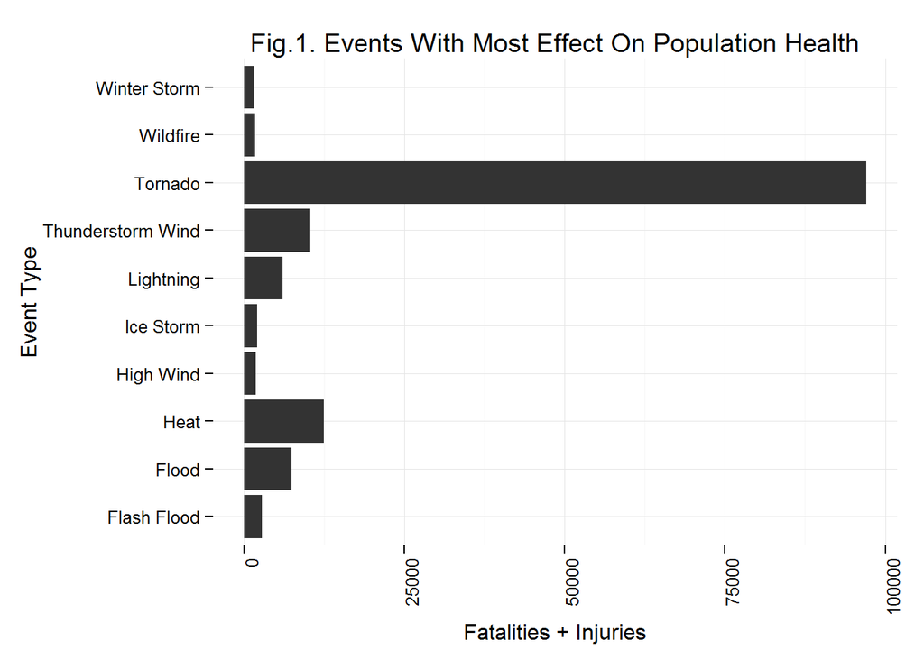

```r
library(ggplot2)
ggplot(NOAA_popu_final[1:10,], aes(x=EVTYPE, y=popul_health)) +
        geom_bar(stat = "identity") +
        ggtitle("Fig.1. Events With Most Effect On Population Health") +
        xlab("Event Type") + ylab("Fatalities + Injuries") + theme_minimal() +
        theme(axis.text.x = element_text(angle = 90, hjust = 1)) + coord_flip()
```

Here is the information in tabular form:

```r
NOAA_popu_final[1:10,]
```

```
## Source: local data frame [10 x 2]
##
##               EVTYPE popul_health
## 1            Tornado        97022
## 2               Heat        12422
## 3  Thunderstorm Wind        10222
## 4              Flood         7385
## 5          Lightning         6048
## 6        Flash Flood         2837
## 7          Ice Storm         2064
## 8          High Wind         1822
## 9           Wildfire         1698
## 10      Winter Storm         1570
```

As can be seen both in the table and the plot, Tornado, Heat, Thunderstorm Wind, Flood and Lightning are the five events most harmful for population health.

### Across the United States, which types of events have the greatest economic consequences?

As in the previous case, only the 10 first event types are plotted.

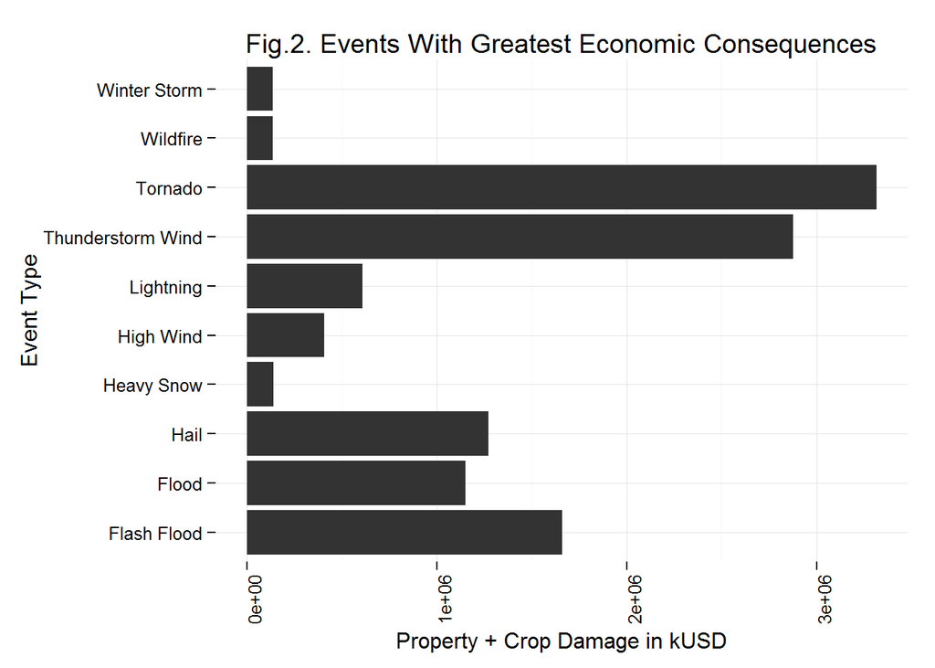

```r
library(ggplot2)
ggplot(NOAA_econ_final[1:10,], aes(x=EVTYPE, y=econ_cons)) +
        geom_bar(stat = "identity") +
        ggtitle("Fig.2. Events With Greatest Economic Consequences") +
        xlab("Event Type") + ylab("Property + Crop Damage in kUSD") + theme_minimal() +
        theme(axis.text.x = element_text(angle = 90, hjust = 1)) + coord_flip()
```

Here is the information in tabular form:

```r
NOAA_econ_final[1:10,]
```

```
## Source: local data frame [10 x 2]
##
##               EVTYPE econ_cons
## 1            Tornado 3314666.9
## 2  Thunderstorm Wind 2874733.3
## 3        Flash Flood 1660846.1
## 4               Hail 1271300.3
## 5              Flood 1148368.9
## 6          Lightning  606977.4
## 7          High Wind  407107.1
## 8         Heavy Snow  138763.1
## 9       Winter Storm  135764.6
## 10          Wildfire  134784.0
```

As can be seen both in the table and the plot, Tornado, Thunderstorm Wind, Flash Flood, Hail and Flood are the five events having most consequences from an economic perspective.